# Bank Review Analysis

**Business Problem:**  
To analyse the customer reviews and predict the customer satisfication through the reviews.

- Data Processing ✓
- Most frequent Pos and Neg words ✓
- Classification of the reviews into Pos, Neg and Neutral ✓
- Predict the rating ✓
- Topic mining ✓

**Approach**

**Importing libraries and dataset**  
**Data Audits**  
**Exploratory Data Analysis**  
**Data Preparation**

> - Train and Test split
> - Creating Corpus

**Frequency distribution of words**

> - Frequency of words
> - Connotation of frequent words

**Classifying the reviews as Positive, Negative or Nuetral**  
**Predicting the Rating of reviews**

> - Bag of words
> - TF-IDF
> - TF-IDF n_gram
> - Model implemetation + Evaluation
>   > - Naive Bayes
>   > - LinearSVC

**Clustering Analysis**

> - Finding Optimum #Clusters
> - K Means
> - Cluster exploration

**Topic Mining**

> - LDA
> - Topic Frequency
> - Topic inspection

Importing the Libraries

```python
import numpy as np
import pandas as pd
import matplotlib.pyplot as plt
import seaborn as sns
from tqdm import tqdm_notebook
```

```python
import re
import string
import nltk
from textblob import TextBlob
from nltk.corpus import stopwords
from nltk.tokenize import word_tokenize
from nltk.stem.porter import PorterStemmer
from nltk.stem import WordNetLemmatizer
```

```python
from sklearn.model_selection  import train_test_split
from sklearn.metrics import confusion_matrix, classification_report, accuracy_score, roc_auc_score
```

Importing the dataset

```python
data = pd.read_excel('BankReviews.xlsx')
```

```python
data.head(3)
```

|  | Date | Stars | Reviews | BankName |
| --- | --- | --- | --- | --- |
| 0 | 2017-04-10 | 5 | Great job, Wyndham Capital! Each person was pr... | Wyndham Capital Mortgage |
| 1 | 2017-02-10 | 5 | Matthew Richardson is professional and helpful... | Wyndham Capital Mortgage |
| 2 | 2017-08-21 | 5 | We had a past experience with Wyndham Mortgage... | Wyndham Capital Mortgage |

**Data Audit**

Check for duplicate reviews

```python
data.duplicated().value_counts()
```

```
False    503
True       2
dtype: int64
```

Check for missing values

```python
data.isnull().sum()
```

```
Date        0
Stars       0
Reviews     0
BankName    0
dtype: int64
```

Check for language of the Reviews

```python
#print(TextBlob(data.Reviews[0]).detect_language())
#print(TextBlob(data.Reviews[-1]).detect_language())
```

**Exploratory Analysis**

```python
df = data.copy()
eng_stopwords = set(stopwords.words("english"))
```

```python
df['Reviews'] = df['Reviews'].astype(str)
df['count_sent']=df["Reviews"].apply(lambda x: len(re.findall("\n",str(x)))+1)

#Word count in each comment:
df['count_word']=df["Reviews"].apply(lambda x: len(str(x).split()))

#Unique word count
df['count_unique_word']=df["Reviews"].apply(lambda x: len(set(str(x).split())))

#Letter count
df['count_letters']=df["Reviews"].apply(lambda x: len(str(x)))

#Word density

#df['word_density'] = df['count_letters'] / (df['count_word']+1)

#punctuation count
df["count_punctuations"] =df["Reviews"].apply(lambda x: len([c for c in str(x) if c in string.punctuation]))

#upper case words count
#df["count_words_upper"] = df["Reviews"].apply(lambda x: len([w for w in str(x).split() if w.isupper()]))

#lower case words count
#df["count_words_lower"] = df["Reviews"].apply(lambda x: len([w for w in str(x).split() if w.islower()]))

#title case words count
df["count_words_title"] = df["Reviews"].apply(lambda x: len([w for w in str(x).split() if w.istitle()]))

#Number of stopwords
df["count_stopwords"] = df["Reviews"].apply(lambda x: len([w for w in str(x).lower().split() if w in eng_stopwords]))

#Average length of the words
#df["mean_word_len"] = df['Reviews'].apply(lambda x: np.mean([len(w) for w in str(x).split()]))

#Number of numeric
df['numeric'] = df['Reviews'].apply(lambda x :len([x for x in x.split() if x.isdigit()]))

#Number of alphanumeric
df['alphanumeric'] = df['Reviews'].apply(lambda x :len([x for x in x.split() if x.isalnum()]))

#Number of alphabetics
df['alphabetics'] = df['Reviews'].apply(lambda x :len([x for x in x.split() if x.isalpha()]))

#Number of spaces
df['Spaces'] = df['Reviews'].apply(lambda x :len([x for x in x.split() if x.isspace()]))

#Number of Words ends with
#df['words_ends_with_et'] = df['Reviews'].apply(lambda x :len([x for x in x.lower().split() if x.endswith('et')]))

#Number of Words ends with
#df['words_start_with_no'] = df['Reviews'].apply(lambda x :len([x for x in x.lower().split() if x.startswith('no')]))

# Count the occurences of all words
#df['wordcounts'] = df['Reviews'].apply(lambda x :dict([ [t, x.split().count(t)] for t in set(x.split()) ]))

pos_family = {
    'noun' : ['NN','NNS','NNP','NNPS'],
    'pron' : ['PRP','PRP$','WP','WP$'],
    'verb' : ['VB','VBD','VBG','VBN','VBP','VBZ'],
    'adj' :  ['JJ','JJR','JJS'],
    'adv' : ['RB','RBR','RBS','WRB']
}

# function to check and get the part of speech tag count of a words in a given sentence
def check_pos_tag(x, flag):
    cnt = 0
    try:
        text=word_tokenize(x)
        wiki = nltk.pos_tag(text)
        for tup in wiki:
            ppo = list(tup)[1]
            if ppo in pos_family[flag]:
                cnt += 1
    except:
        #print('e')
        pass
    return cnt

df['noun_count'] = df['Reviews'].apply(lambda x: check_pos_tag(x, 'noun'))
df['verb_count'] = df['Reviews'].apply(lambda x: check_pos_tag(x, 'verb'))
df['adj_count']  = df['Reviews'].apply(lambda x: check_pos_tag(x, 'adj'))
df['adv_count']  = df['Reviews'].apply(lambda x: check_pos_tag(x, 'adv'))
df['pron_count'] = df['Reviews'].apply(lambda x: check_pos_tag(x, 'pron'))
```

```python
df.head(3)
```

|  | Date | Stars | Reviews | BankName | count_sent | count_word | count_unique_word | count_letters | count_punctuations | count_words_title | count_stopwords | numeric | alphanumeric | alphabetics | Spaces | noun_count | verb_count | adj_count | adv_count | pron_count |
| --- | --- | --- | --- | --- | --- | --- | --- | --- | --- | --- | --- | --- | --- | --- | --- | --- | --- | --- | --- | --- |
| 0 | 2017-04-10 | 5 | Great job, Wyndham Capital! Each person was pr... | Wyndham Capital Mortgage | 1 | 19 | 19 | 126 | 4 | 5 | 5 | 0 | 15 | 15 | 0 | 7 | 4 | 1 | 1 | 3 |
| 1 | 2017-02-10 | 5 | Matthew Richardson is professional and helpful... | Wyndham Capital Mortgage | 1 | 25 | 23 | 159 | 4 | 5 | 10 | 0 | 21 | 21 | 0 | 7 | 3 | 4 | 2 | 4 |
| 2 | 2017-08-21 | 5 | We had a past experience with Wyndham Mortgage... | Wyndham Capital Mortgage | 1 | 79 | 64 | 462 | 8 | 14 | 31 | 0 | 73 | 73 | 0 | 23 | 10 | 6 | 8 | 8 |

```python
#df.to_excel('Bank_audit.xlsx')
```

**Data Preparation**

Train and Test split

```python
# define X and y
X = data.Reviews
y = data.Stars

# split the new DataFrame into training and testing sets
X_train, X_test, y_train, y_test = train_test_split(X, y,test_size=0.2,random_state=1)

X_train = X_train.reset_index(drop=True)
X_test = X_test.reset_index(drop=True)
y_train = y_train.reset_index(drop=True)
y_test = y_test.reset_index(drop=True)

X_train.shape,X_test.shape,y_train.shape,y_test.shape
```

```
((404,), (101,), (404,), (101,))
```

Creating the corpus

create_corpus() - Does data cleaning, tokenization, stemming and lemmatization

```python
def create_corpus(x):
    corpus = []
    wn = WordNetLemmatizer()
    ps = PorterStemmer()
    for i in tqdm_notebook(range(0, x.shape[0])):
        #print(i,end='\r')
        msg = re.sub('[^a-zA-Z]', ' ', x[i])
        msg = msg.lower()
        msg = msg.split()
        #msg = word_tokenize(X_train[i].lower()) #Not preferred as it doesn't handle metachars, numbers
        msg = [wn.lemmatize(word) for word in msg if not word in set(eng_stopwords)] #wn.lemmatize #ps.stem
        msg = ' '.join(msg)
        corpus.append(msg)
        #break
    return corpus
```

```python
X_train =create_corpus(X_train)
X_test =create_corpus(X_test)
```

### ----------------------------------------------------------------------------------------------------------------------------

## Frequency distribution of words

```python
freq_words= {}
pattern = re.compile(r'\W')
for r in data['Reviews']:
    tokens = nltk.wordpunct_tokenize(r.lower())
    for token in tokens:
        if token.lower() not in eng_stopwords:
            if not pattern.search(token.lower()):
                if token in freq_words:
                    count = freq_words[token]
                    count = count + 1
                    freq_words[token] = count
                else:
                    freq_words[token] = 1
```

```python
freq_words = pd.DataFrame(freq_words,index=range(len(freq_words))).T[[0]].sort_values(by=0,ascending=False)
freq_words.columns = ['counts']
freq_words.head(10)
```

|  | counts |
| --- | --- |
| loan | 313 |
| process | 253 |
| would | 246 |
| us | 207 |
| home | 191 |
| read | 190 |
| time | 189 |
| recommend | 156 |
| mortgage | 147 |
| great | 139 |

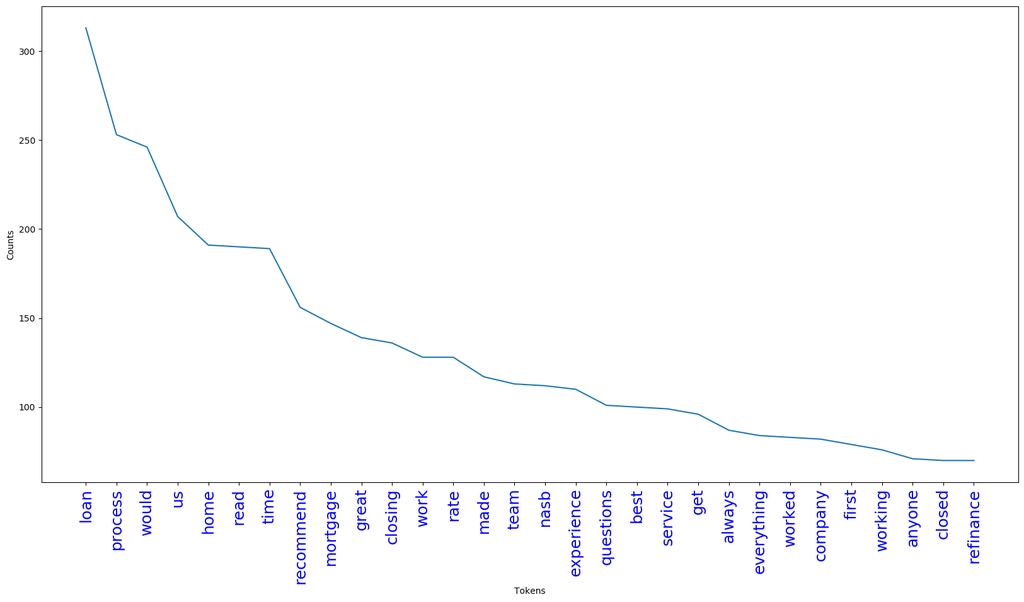

```python
plt.figure(figsize=(20,10),dpi=100)
plt.plot('counts',data=freq_words.head(30))
plt.xlabel('Tokens')
plt.ylabel('Counts')
plt.xticks(rotation=90,fontsize=18,color='b')
plt.show()
```

Word Cloud

```python
import wordcloud
from wordcloud import WordCloud
```

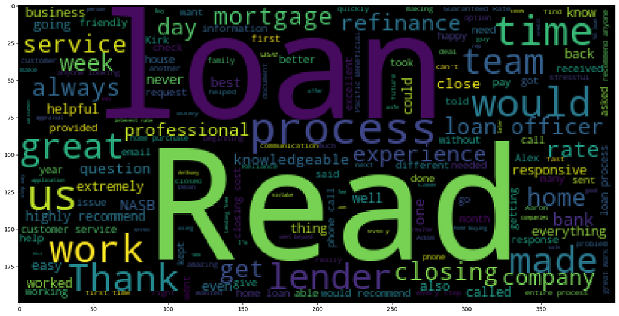

```python
wordcloud = WordCloud(stopwords=eng_stopwords).generate(' '.join(X.tolist()))
fig = plt.figure(figsize=(20,10),dpi=100)
plt.imshow(wordcloud)
```

Finding the connotations frequent words

```python
freq_set = set(freq_words.index)
freq_sent = []
for x in freq_set:
    analysis = TextBlob(x)
    # set sentiment
    if analysis.sentiment.polarity > 0:
        freq_sent.append('pos')
    elif analysis.sentiment.polarity == 0:
        freq_sent.append('neut')
    else:
        freq_sent.append('neg')
```

```python
freq_dict = {'words':list(freq_set), 'sentiment':freq_sent}
freq_df = pd.DataFrame(freq_dict)
```

```python
print('Words counts - Positive :{} Negative :{}'.format(freq_df[freq_df.sentiment == 'pos'].shape[0], freq_df[freq_df.sentiment == 'neg'].shape[0]))
```

```
Words counts - Positive :212 Negative :104
```

### ----------------------------------------------------------------------------------------------------------------------------

## Classifying the reviews as Positive, Negative or Neutral

```python
# We use textblob utility to calculate polarity
def get_sentiment(x):
    # create TextBlob object of passed text
    analysis = TextBlob(x)
    # set sentiment
    if analysis.sentiment.polarity > 0:
        return 'positive'
    elif analysis.sentiment.polarity == 0:
        return 'neutral'
    else:
        return 'negative'
```

```python
text = X_train.copy()
text = pd.Series(text)
```

```python
sentiment = text.apply(lambda x: get_sentiment(x))
Table = pd.concat([text,sentiment],axis=1)
Table.columns = ['review','sentiment']
```

```python
Table.head(3)
```

|  | review | sentiment |
| --- | --- | --- |
| 0 | got best deal price matched even better fortun... | positive |
| 1 | started refinance nick thing going ok problem ... | positive |
| 2 | easy going extra mile overcoming obstacle trut... | positive |

```python
pos_review = Table[Table.sentiment == 'positive']
neg_review = Table[Table.sentiment == 'negative']
neut_review = Table[Table.sentiment == 'neutral']
```

```python
print('Percentages of reviews :')
print('Positive - {} %'.format(len(pos_review)*100/len(Table)))
print('Negative - {} %'.format(len(neg_review)*100/len(Table)))
print('Neutral  - {} %'.format(len(neut_review)*100/len(Table)))
```

```
Percentages of reviews :
Positive - 89.60396039603961 %
Negative - 7.920792079207921 %
Neutral  - 2.4752475247524752 %
```

```python
pos_review.review.tail(1).tolist()
```

```
['peter team great work professional prompt response answered question somehow got u closing time despite various roadblock encountered']
```

```python
neg_review.review.tail(1).tolist()
```

```
['called second submitting lending tree form asked could run number later found pulling credit score without permission didnt ask specific emailed preapproval letter horrible rate']
```

```python
neut_review.review[64]
```

```
'bob triumph beat lender rate prompt approval closing'
```

### ----------------------------------------------------------------------------------------------------------------------------

## Predicting the Ratings

**Bag of Words model** (Count Vectorizer)

```python
# Creating the Bag of Words model
from sklearn.feature_extraction.text import CountVectorizer
```

```python
cv = CountVectorizer(min_df=2)
X_train_bow = cv.fit_transform(X_train).toarray()
X_test_bow = cv.transform(X_test).toarray()
```

```python
X_train_bow.shape,X_test_bow.shape
```

```
((404, 1350), (101, 1350))
```

**TF - IDF model**

```python
from sklearn.feature_extraction.text import TfidfVectorizer
```

```python
tv = TfidfVectorizer(min_df=2)
```

```python
X_train_tv = tv.fit_transform(X_train).toarray()
X_test_tv = tv.transform(X_test).toarray()
```

```python
X_train_tv.shape,X_test_tv.shape
```

```
((404, 1350), (101, 1350))
```

**TF - IDF n_gram model**

```python
tv_ngram = TfidfVectorizer(min_df=2, ngram_range=(1, 2),max_features=1350)
X_train_tv_ng =  tv_ngram.fit_transform(X_train)
X_test_tv_ng =  tv_ngram.transform(X_test)
```

```python
X_train_tv_ng.shape, X_test_tv_ng.shape
```

```
((404, 1350), (101, 1350))
```

**Model for predicting the Ratings**

- Naive Bayes
- LinearSVC

```python
def pred_rate(cls, X_train, X_test, y_train, y_test):
    # fitting
    cls.fit(X_train, y_train)
    # pred
    y_pred_train = cls.predict(X_train)
    y_pred_test = cls.predict(X_test)

    print('cm train\n',confusion_matrix(y_train, y_pred_train))
    print('cm test \n',confusion_matrix(y_test, y_pred_test))

    accuracy = accuracy_score(y_train, y_pred_train)
    print("\nAccuracy train : {} %".format(round(accuracy*100,3)))
    accuracy = accuracy_score(y_test, y_pred_test)
    print("Accuracy test  : {} %".format(round(accuracy*100,3)))

    train_auc = roc_auc_score(y_train, y_pred_train)
    test_auc  = roc_auc_score(y_test, y_pred_test)
    print("\nAUC Train : ", train_auc)
    print("AUC Test  : ", test_auc)

    print('\nClassification Report Train :')
    print(classification_report(y_train, y_pred_train))
    print('\nClassification Report Test :')
    print(classification_report(y_test, y_pred_test))
    print('-----------------------------------------------------------')
```

**Naive Bayes**

```python
# Fitting Naive Bayes to the train_saming set
from sklearn.naive_bayes import MultinomialNB
cls_nb = MultinomialNB()
```

```python
# Bag of words
print('Bag of words')
pred_rate(cls_nb, X_train_bow,X_test_bow,y_train,y_test)
# Tf-idf
print('\nTf-idf')
pred_rate(cls_nb, X_train_tv,X_test_tv,y_train,y_test)
# Tf-idf ngram
print('\nTf-idf ngram')
pred_rate(cls_nb, X_train_tv_ng,X_test_tv_ng,y_train,y_test)
```

```
Bag of words
cm train
 [[ 73   3]
 [  3 325]]
cm test
 [[16  3]
 [ 2 80]]

Accuracy train : 98.515 %
Accuracy test  : 95.05 %

AUC Train :  0.9756899871630295
AUC Test  :  0.9088575096277277

Classification Report Train :
              precision    recall  f1-score   support

           1       0.96      0.96      0.96        76
           5       0.99      0.99      0.99       328

    accuracy                           0.99       404
   macro avg       0.98      0.98      0.98       404
weighted avg       0.99      0.99      0.99       404


Classification Report Test :
              precision    recall  f1-score   support

           1       0.89      0.84      0.86        19
           5       0.96      0.98      0.97        82

    accuracy                           0.95       101
   macro avg       0.93      0.91      0.92       101
weighted avg       0.95      0.95      0.95       101

-----------------------------------------------------------

Tf-idf
cm train
 [[ 50  26]
```

[output cut: 55 more lines]

```
   macro avg       0.96      0.84      0.88       404
weighted avg       0.94      0.94      0.93       404


Classification Report Test :
              precision    recall  f1-score   support

           1       1.00      0.47      0.64        19
           5       0.89      1.00      0.94        82

    accuracy                           0.90       101
   macro avg       0.95      0.74      0.79       101
weighted avg       0.91      0.90      0.89       101

-----------------------------------------------------------
```

**Linear SVC**

```python
y_train.value_counts()
```

```
5    328
1     76
Name: Stars, dtype: int64
```

```python
328/404,76/404
```

```
(0.8118811881188119, 0.18811881188118812)
```

```python
from sklearn.svm import LinearSVC
cls_svc = LinearSVC(class_weight={5:0.81,1:.188})
```

```python
# Bag of words
print('Bag of words')
pred_rate(cls_svc, X_train_bow,X_test_bow,y_train,y_test)
# Tf-idf
print('\nTf-idf')
pred_rate(cls_svc, X_train_tv,X_test_tv,y_train,y_test)
# Tf-idf ngram
print('\nTf-idf ngram')
pred_rate(cls_svc, X_train_tv_ng,X_test_tv_ng,y_train,y_test)
```

```
Bag of words
```

```
cm train
 [[ 74   2]
 [  0 328]]
cm test
 [[14  5]
 [ 0 82]]

Accuracy train : 99.505 %
Accuracy test  : 95.05 %

AUC Train :  0.986842105263158
AUC Test  :  0.868421052631579

Classification Report Train :
              precision    recall  f1-score   support

           1       1.00      0.97      0.99        76
           5       0.99      1.00      1.00       328

    accuracy                           1.00       404
   macro avg       1.00      0.99      0.99       404
weighted avg       1.00      1.00      1.00       404


Classification Report Test :
              precision    recall  f1-score   support

           1       1.00      0.74      0.85        19
           5       0.94      1.00      0.97        82

    accuracy                           0.95       101
   macro avg       0.97      0.87      0.91       101
weighted avg       0.95      0.95      0.95       101

-----------------------------------------------------------

Tf-idf
cm train
 [[ 58  18]
 [  0 328]]
```

[output cut: 54 more lines]

```
   macro avg       0.98      0.89      0.93       404
weighted avg       0.96      0.96      0.96       404


Classification Report Test :
              precision    recall  f1-score   support

           1       1.00      0.53      0.69        19
           5       0.90      1.00      0.95        82

    accuracy                           0.91       101
   macro avg       0.95      0.76      0.82       101
weighted avg       0.92      0.91      0.90       101

-----------------------------------------------------------
```

**Inference :** *The bag of words model of Naive Bayes and Linear SVC performs comparatively better considering the accuracy and classfication report metrics*

### ----------------------------------------------------------------------------------------------------------------------------

## Cluster Analysis

**Kmeans Clustering**

finding the optimum number of clusters

```python
from sklearn.cluster import KMeans
from sklearn.decomposition import PCA
```

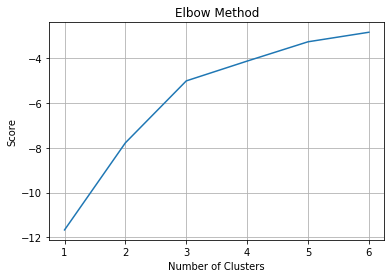

```python
pca = PCA(n_components = 2)
X_pcs = pca.fit_transform(X_train_tv)

kmeans = [KMeans(n_clusters=i, max_iter=300) for i in range(1,7)]

score = [kmeans[i].fit(X_pcs).score(X_pcs) for i in range(len(kmeans))]

plt.plot(list(range(1,7)), score)
plt.xlabel('Number of Clusters')
plt.ylabel('Score')
plt.title('Elbow Method')
plt.grid()
plt.show()
```

from the plot the optimum clusters can be 3

Implementing the model

# 3 Clusters

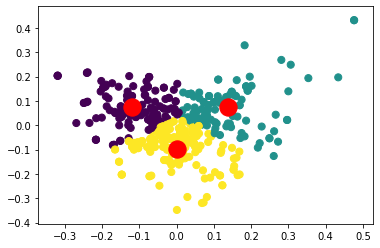

```python
k_mod = KMeans(n_clusters=3, max_iter=300, init='k-means++')
k_mod.fit(X_pcs)
predicted_values = k_mod.predict(X_pcs)

plt.scatter(X_pcs[:, 0], X_pcs[:, 1], c=predicted_values, s=50)  # cmap='viridis'
plt.scatter(k_mod.cluster_centers_[:, 0], k_mod.cluster_centers_[:, 1], s = 300, c = 'r', label = 'Centroids')
```

```python
predicted_values;
```

```python
def get_top_features_cluster(X_train_tv, prediction, n_feats):
    labels = np.unique(prediction)
    dfs = []
    for label in labels:
        id_temp = np.where(prediction==label) # indices for each cluster
        x_means = np.mean(X_train_tv[id_temp], axis = 0) # returns average score across cluster
        sorted_means = np.argsort(x_means)[::-1][:n_feats] # indices with top 20 scores
        features = tv.get_feature_names()
        best_features = [(features[i], x_means[i]) for i in sorted_means]
        df = pd.DataFrame(best_features, columns = ['features', 'score'])
        dfs.append(df)
    return dfs
```

```python
df1,df2,df3 = get_top_features_cluster(X_train_tv, predicted_values, 15)
```

**Cluster 1**

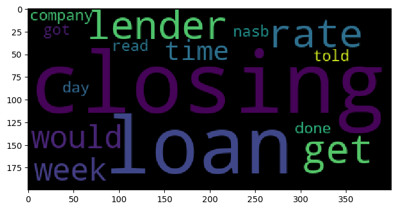

```python
wordcloud = WordCloud(stopwords=[]).generate(' '.join(df1.features.tolist()))
fig = plt.figure(figsize=(8,4),dpi=100)
plt.imshow(wordcloud)
```

**Cluster 2**

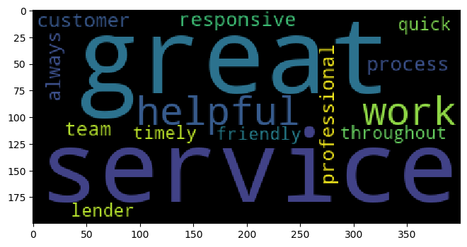

```python
wordcloud = WordCloud(stopwords=[]).generate(' '.join(df2.features.tolist()))
fig = plt.figure(figsize=(8,4),dpi=100)
plt.imshow(wordcloud)
```

**Cluster 3**

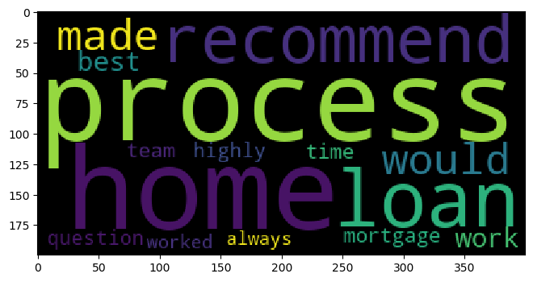

```python
wordcloud = WordCloud(stopwords=[]).generate(' '.join(df3.features.tolist()))
fig = plt.figure(figsize=(8,4),dpi=100)
plt.imshow(wordcloud)
```

### ----------------------------------------------------------------------------------------------------------------------------

## Topic Modelling

```python
import gensim
from gensim import corpora
from sklearn.decomposition import LatentDirichletAllocation as LDA
```

```python
X_train_token = pd.Series(X_train).map(word_tokenize)
```

```python
X_train_dict = corpora.Dictionary(X_train_token)
X_train_dict.filter_extremes(no_below=3, no_above=0.9)
```

```python
dtm = [X_train_dict.doc2bow(d) for d in X_train_token]
```

```python
lda = gensim.models.ldamodel.LdaModel(dtm,num_topics=10,alpha='auto',chunksize=10,id2word=X_train_dict,passes=20)
```

```python
topics  = lda.get_document_topics(dtm)
```

```python
lda.show_topics()
```

```
[(0,
  '0.100*"would" + 0.073*"company" + 0.036*"bank" + 0.029*"mortgage" + 0.025*"never" + 0.025*"thing" + 0.024*"quick" + 0.022*"called" + 0.020*"respond" + 0.019*"received"'),
 (1,
  '0.091*"every" + 0.057*"way" + 0.053*"deal" + 0.051*"financing" + 0.049*"done" + 0.047*"well" + 0.039*"interest" + 0.038*"step" + 0.038*"response" + 0.034*"want"'),
 (2,
  '0.054*"loan" + 0.049*"great" + 0.036*"mortgage" + 0.028*"service" + 0.027*"best" + 0.025*"team" + 0.025*"worked" + 0.022*"lender" + 0.022*"alex" + 0.021*"refinance"'),
 (3,
  '0.082*"process" + 0.059*"home" + 0.052*"time" + 0.045*"question" + 0.044*"recommend" + 0.037*"always" + 0.035*"made" + 0.032*"experience" + 0.030*"work" + 0.030*"easy"'),
 (4,
  '0.070*"house" + 0.065*"friend" + 0.059*"know" + 0.059*"jon" + 0.056*"barrett" + 0.051*"phone" + 0.034*"job" + 0.033*"mr" + 0.033*"recommended" + 0.033*"another"'),
 (5,
  '0.070*"closing" + 0.043*"option" + 0.041*"email" + 0.034*"helped" + 0.034*"day" + 0.029*"refinancing" + 0.027*"good" + 0.026*"back" + 0.022*"without" + 0.022*"peter"'),
 (6,
  '0.065*"got" + 0.062*"go" + 0.054*"adam" + 0.042*"even" + 0.038*"find" + 0.038*"fantastic" + 0.032*"people" + 0.030*"better" + 0.030*"document" + 0.026*"online"'),
 (7,
  '0.132*"u" + 0.053*"work" + 0.033*"answered" + 0.027*"thank" + 0.026*"certainly" + 0.025*"hard" + 0.025*"care" + 0.024*"able" + 0.023*"kept" + 0.023*"issue"'),
 (8,
  '0.063*"rate" + 0.047*"went" + 0.037*"week" + 0.034*"get" + 0.033*"customer" + 0.024*"time" + 0.024*"read" + 0.023*"took" + 0.020*"call" + 0.019*"provided"'),
 (9,
  '0.076*"need" + 0.046*"nasb" + 0.028*"loan" + 0.026*"anything" + 0.022*"fee" + 0.019*"selling" + 0.019*"various" + 0.018*"explaining" + 0.017*"letter" + 0.016*"market"')]
```

Topic Frequency

```python
from operator import itemgetter
```

```python
top = [max(t, key=itemgetter(1))[0] for t in topics]
```

```python
top = pd.Series(top)
```

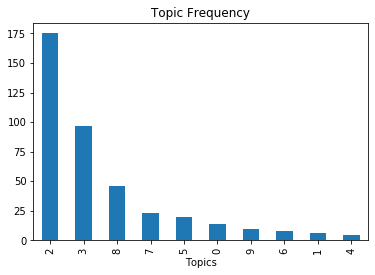

```python
top.value_counts().plot(kind='bar')
plt.xlabel('Topics')
plt.title('Topic Frequency')
plt.show()
```

### ----------------------------------------------------------------------------------------------------------------------------

```python
import re
```

```python
pattern  = re.compile(r'nasb')
```

```python
l = [pattern.finditer(X_train[i]) for i in range(len(X_train))]
```

```python
c=1
for i in l:
    for j in i:
        print(j)
        c+=1
    if c>5:
        break
```

```
<re.Match object; span=(296, 300), match='nasb'>
<re.Match object; span=(546, 550), match='nasb'>
<re.Match object; span=(73, 77), match='nasb'>
<re.Match object; span=(204, 208), match='nasb'>
<re.Match object; span=(582, 586), match='nasb'>
```

### ----------------------------------------------------------------------------------------------------------------------------